# Inverse Problems in Geophysics Part 10: Nonlinear minimization

2. MGPY+MGIN

Thomas Günther  
thomas.guenther@geophysik.tu-freiberg.de

# Recap

- non-linear problems linearized: $\vb S \Delta \vb m=\Delta\vb d$
- sensitivity: derivative of forward response $\pdv*{f_i}{m_j}$
- Jacobian: sensitivity with model & data transforms (inner derivatives)
- objective function $\Phi=\Phi_d+\lambda\Phi_m$ (data + model)
- model update in direction of negative gradient $\Rightarrow$ Steepest Descent

# A simple problem

Formula for 2 model parameters $m_1$/$m_2$ & data measured at $x$
$$f(m)= \sin(\omega m_1 x_i) + m_1 m_2$$

Derivatives:
$$\frac{\partial f(m)}{\partial m_1} = \omega x_i \cos(\omega m_1 x_i) + m_2$$
$$\frac{\partial f(m)}{\partial m_2} = m_1$$

## A simple minimization problem

$$f(m)= \sin(\omega m_1 x_i) + m_1 m_2$$

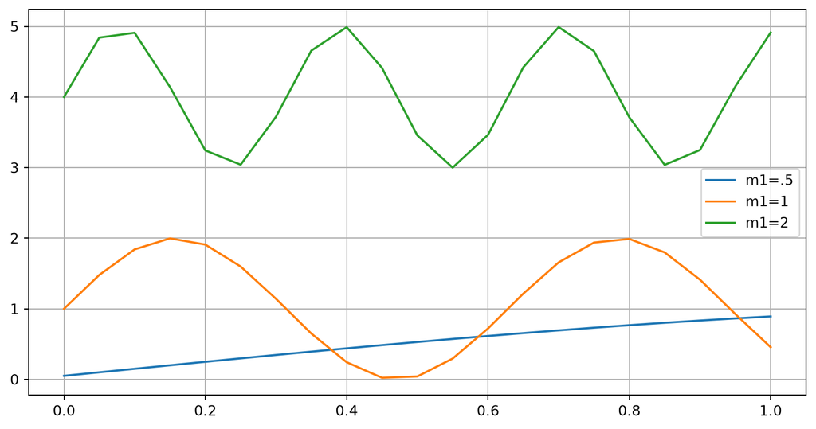

```python
x = np.arange(0, 1.001, 0.05)
om = 10
forward = lambda m: np.sin(om*x*m[0])+m[0]*m[1]
plt.plot(x, forward([0.1, 0.5]), label="m1=.5")
plt.plot(x, forward([1, 1]), label="m1=1")
plt.plot(x, forward([2, 2]), label="m1=2");
plt.grid()
plt.legend();
```

## Synthetic data

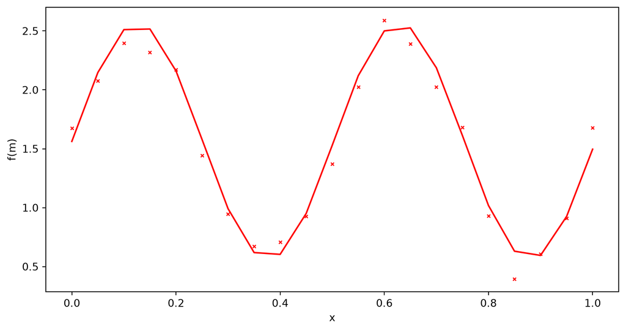

```python
mSynth = [1.25, 1.25]
data = forward(mSynth);
plt.plot(x, data, "r-")
data += np.random.randn(len(data))*0.1;
plt.plot(x, data, "rx");
plt.xlabel("x")
plt.ylabel("f(m)");
```

## Objective function

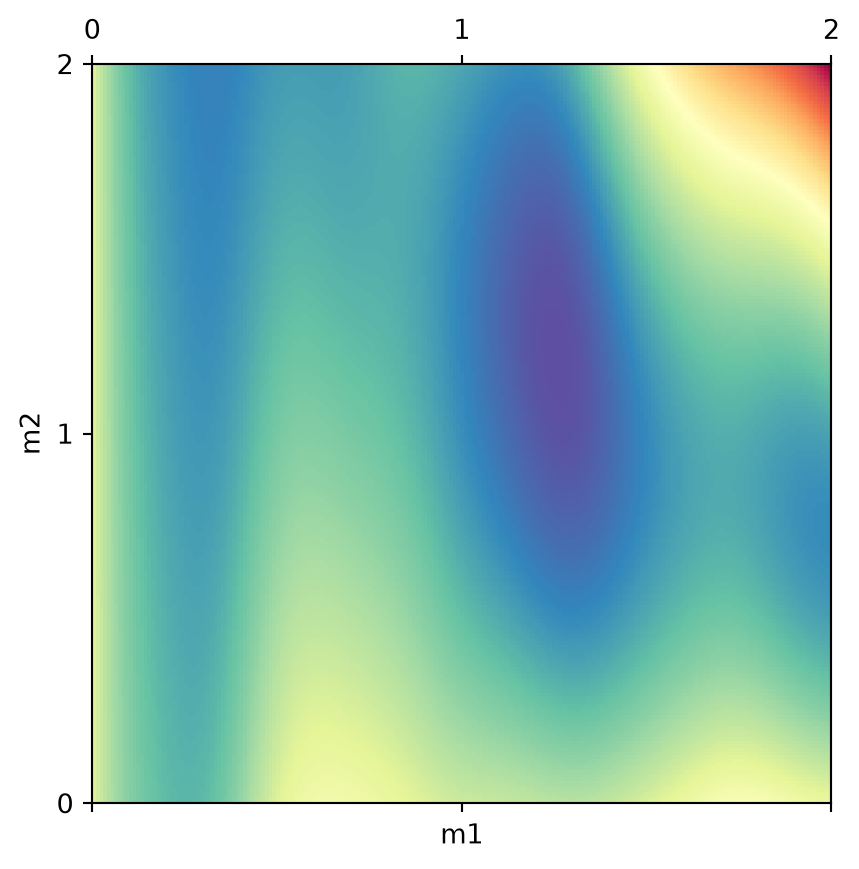

```python
ms = np.arange(0, 2.001, 0.01)
Phi = np.zeros([len(ms), len(ms)])
for i, m1 in enumerate(ms):
    for j, m2 in enumerate(ms):
        Phi[i, j] = sum((data-forward([m1, m2]))**2)

fig, ax = plt.subplots()
ax.matshow(Phi.T, cmap="Spectral_r",
    extent=ms[[0, -1, -1, 0]])
ax.set_xlabel("m1")
ax.set_ylabel("m2")
ax.invert_yaxis();
```

## Objective function

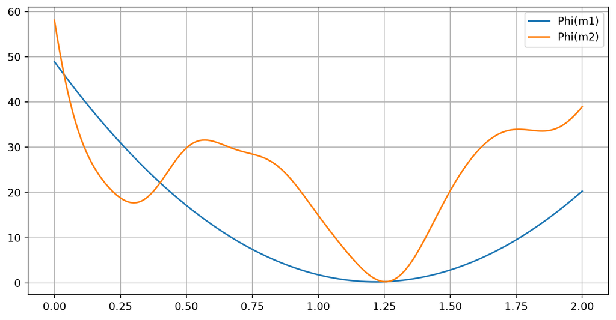

```python
plt.plot(ms, Phi[int(mSynth[0]*100), :],
         label="Phi(m1)")
plt.plot(ms, Phi[:, int(mSynth[1]*100)],
         label="Phi(m2)")
plt.grid()
plt.legend();
```

## Gradient methods

$$\Phi_d=(\vb d - \vb f(\vb m))^T (\vb d - \vb f(\vb m))$$

$$\vb b=\grad \Phi_d=-2\vb S^T(\vb d - \vb f(\vb m)) \quad\mbox{with}\quad S_{ij}=\pdv{f_i(\vb m^0)}{m_j}$$

**Steepest descent method**: $\Delta\vb m =\vb\nu = - \vb b/|\vb b|$

Regularization: $\Phi=\Phi_d+\lambda\Phi_m=\Phi_d+\lambda(\vb c - \vb C\vb m)^T (\vb c - \vb C\vb m)$

$$\vb b=\grad \Phi=-2\vb S^T(\vb d - \vb f(\vb m))-2\vb C^T(\vb c - \vb C\vb m)$$

## Line search using Armijo rule

$$\vb m^{k+1} = \vb m^{k} + \alpha\nu$$

**Armijo’s rule to determine $\alpha$**

$$\Phi_d(\vb m^{k+1}) \le \Phi_d(\vb m^{k})+c\alpha\vb\nu^T \grad\Phi_d$$

- $c$-empirical constant, typically 1e-4
- start with large $\alpha$ and decrease until rule is fulfilled

$\Rightarrow$ Notebook on simple model

## Gauss-Newton method

$$B_{ij} = \pdv{\Phi_d}{m_i}{m_j} = \pdv{b_i}{m_j} \approx 2\vb S^T\vb S$$

$\Rightarrow \vb m - \vb m^0 = -\vb B^{-1} \vb b = (\vb S^T\vb S)^{-1} \vb S^T (\vb d - \vb f(\vb m))$

$\Rightarrow$ least-squares solution for $\Delta\vb m$/$\Delta\vb d$

with regularization term $\vb B = 2\vb S^T\vb S + 2\lambda\vb C^T\vb C$

$$\Rightarrow \Delta\vb m = (\vb S^T\vb S + \lambda\vb C^T\vb C)^{-1}(\vb S^T(\vb d-\vb f(\vb m)) + \lambda\vb C^T(\vb c-\vb C\vb m))$$

## Gauss-Newton minimization

1. Choose starting model $\vb m^0$ ($n$=0) & compute model response $\vb f(\vb m^n)$
2. Compute sensitivity matrix $\vb S^n$
3. Solve linearized subproblem
   $$\Delta\vb m = (\vb S^T\vb S + \lambda\vb C^T\vb C)^{-1}(\vb S^T(\vb d-\vb f(\vb m)) + \lambda\vb C^T(\vb c-\vb C\vb m))$$
4. Optimize step length $\tau^n$ & update model: $\vb m^{n+1} = \vb m^n + \tau^n \Delta\vb m^n$
5. Compute model response & check convergence: proceeed with 2.
- maximum iteration number, decrease of $\Phi$, reaching target $\chi^2=1$

## Gradient vs. Newton (Menke)

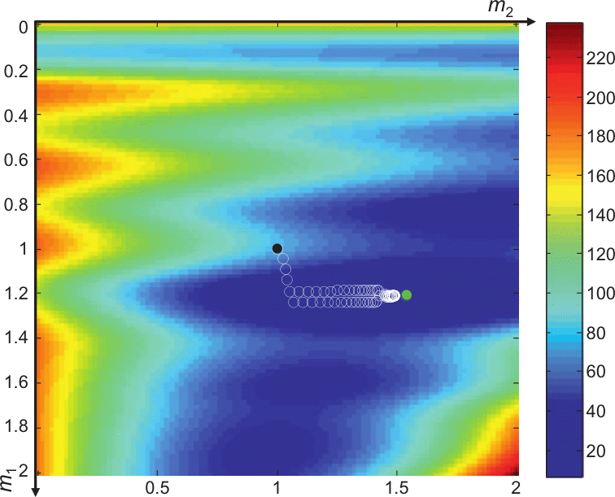

Gradient method

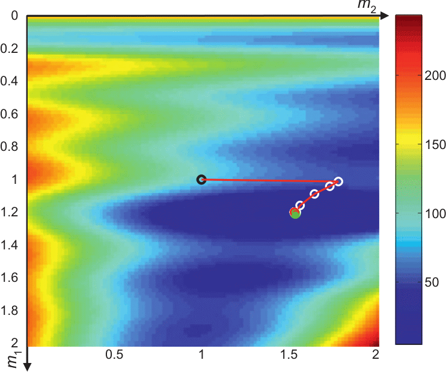

Newtons method

## Local vs. global regularization

Penalizing size or smoothness of

- the model update $\Delta\vb m$ (local) or
- the model $\vb m$ (global)

## Levenberg-Marquardt algorithm

local damping of $\Delta\vb m$ (for stabilizing only)

$$\Delta\vb m = (\vb J^T\vb J+\lambda \vb I)^{-1}\vb J^T(\vb d-\vb f(\vb m))$$

typically used for independent parameters:

- coefficients of fitting (e.g. petrophysical) models
- physical parameters & layer thicknesses of (few) layered model
- often used with logarithmic parameters preventing negatives
- $\lambda$ usually decreased, i.e. $\lambda^k=\lambda^0 v^k$ (e.g., $v$=0.5 etc.)

## Occam (smoothness-constrained) inversion

global regularization of the smoothness $\|\vb C \vb m\|$

$$\Delta\vb m = (\vb S^T\vb S + \lambda\vb C^T\vb C)^{-1}(\vb S^T(\vb d-\vb f(\vb m)) - \lambda\vb C^T\vb C\vb m))$$

used for pre-discretized models: 1D, 2D, 3D, 4D

- full application of Gauss-Newton minimization
- different types of smoothness: 1st/2nd order, geostatistics
- decoupling different regions, region-wise regularization etc.
- regularization parameter $\lambda$ often kept constant or slightly cooled

# Resolution of non-linear inverse problems

- for linear problems directly using system matrix $\vb G$:

$$\vb R^M=\vb G^\dagger\vb G$$

$$\vb R^D=\vb G\vb G^\dagger$$

## Resolution matrices for non-linear problems

$$\vb m^{k+1} = \vb m^k + \vb S^\dagger (\vb d-\vb f(\vb m)) + \vb C^\dagger \vb C (\vb m^0 - \vb m^k)$$

with

$$\vb S^\dagger = (\vb S^T\vb S + \lambda \vb C^T\vb C)^{-1} \vb S^T$$

$$\vb C^\dagger = (\vb S^T\vb S + \lambda \vb C^T\vb C)^{-1} \vb C^T$$

and their combination $\vb S^\dagger\vb S+\vb C^\dagger\vb C=\vb I$

## Model resolution for non-linear problems

$$\vb m^{k+1} = \vb m^k + \vb S^\dagger (\vb d-\vb f(\vb m)) + \vb C^\dagger \vb C (\vb m^0 - \vb m^k)$$

assuming we “come close”, i.e. $\vb m^{est}=\vb m^{k+1}$ and $\Delta\vb m^k$ is small. With

$$\vb d = \vb f(\vb m^{true}) + \vb n = \vb f(\vb m^k) + \vb S(\vb m^{true}-\vb m^k) + \vb n$$

$$\Rightarrow \vb m^{est} = \vb m^k + \vb S^\dagger \vb S (\vb m^{true}-\vb m^k) + \vb C^\dagger \vb C (\vb m^0 - \vb m^k) + \vb S^\dagger \vb n$$

$$\Rightarrow \vb m^{est} = \vb m^k + \vb S^\dagger \vb S \vb m^{true} - (\vb S^\dagger \vb S+\vb C^\dagger \vb C)\vb m^k + \vb C^\dagger \vb C \vb m^0 + \vb S^\dagger \vb n$$

$$\Rightarrow \vb m^{est} = \vb R^M \vb m^{true} + (\vb I - \vb R^M) \vb m^0 + \vb S^\dagger \vb n$$

## Data resolution for non-linear problems

$$\vb f(\vb m^{k+1}) = \vb S(\vb S^\dagger (\vb f(\vb m^{true})+\vb d-\vb f(\vb m^k))) + \vb C^\dagger \vb C (\vb m^0-\vb m^k)$$

$$\vb f(\vb m^{est}) = \vb R^D \vb f(\vb m^{true}) + \vb R^D \vb n + (\vb I - \vb R^D)\vb f(\vb m^0)$$

$$\vb f(\vb m^{est}) = \vb R^D (\vb f(\vb m^{true}) + \vb n) + (\vb I - \vb R^D)\vb f(\vb m^0)$$

$$\vb f(\vb m^{est}) = \vb R^D \vb d + (\vb I - \vb R^D)\vb f(\vb m^0)$$

Response through data space & starting response through null space

## Model resolution for non-linear problems

- resolution matrices $\vb R^M$ and $\vb R^D$ formed just like in linear inversion but with $\vb S^k$
- as $\vb S^k$ depends on $\vb m^k$ (near true), resolution is model-dependent
- all derived properties as before

## Newton’s method (Menke, 2012)

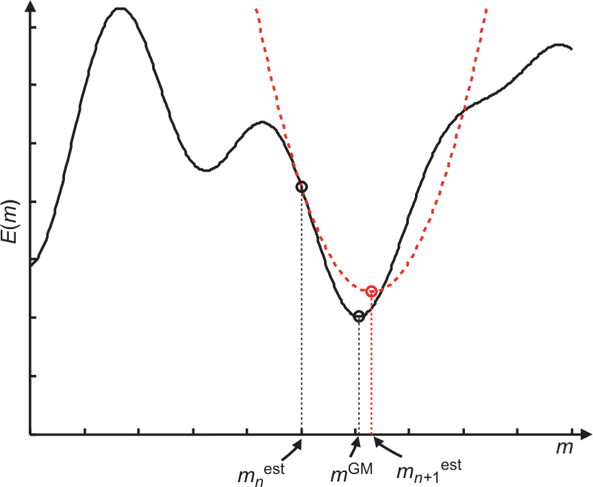

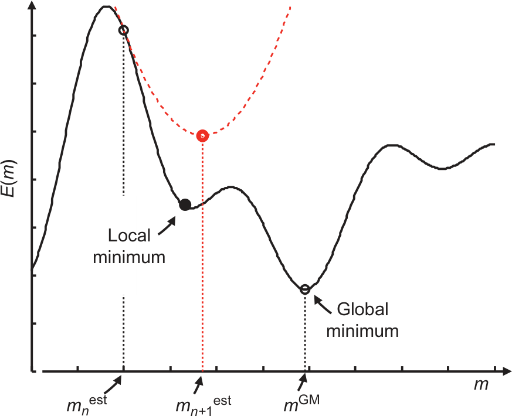

linearize with value, slope and curvature of $\Phi_d$

# Alternatives to grid search

**Monte Carlo search**

draw random samples and accept them if the error is improved

undirected search (Newtons method is directed)

**Simulated annealing**

decrease temperature controlling particle movements:

high $T$: undirected, low $T$: search in vicinity of current model

## Monte Carlo vs. Simulated Annealing

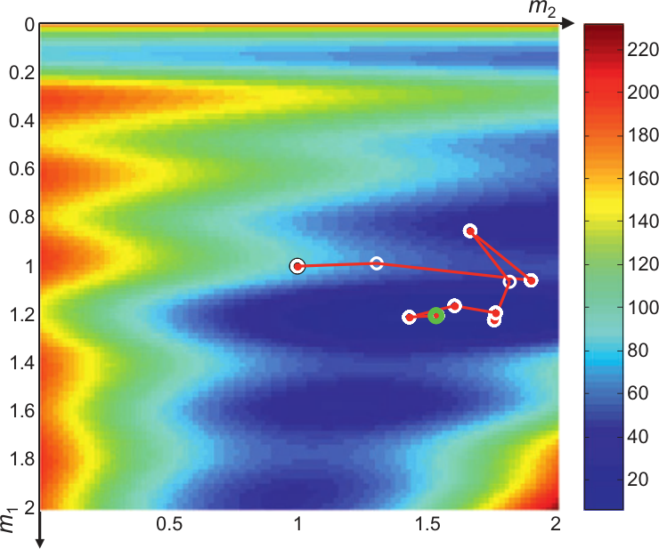

Monte Carlo method

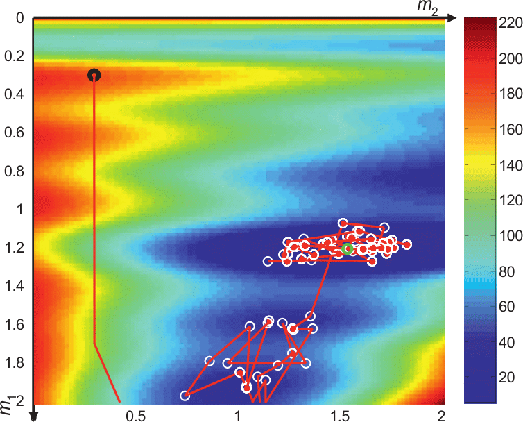

Simulated Annealing

## Monte Carlo methods

- Monte Carlos search: randomly draw solutions from grid
- accept solution only if better than old
- Markow-Chain-Monte-Carlo
- Metropolis-Hastings (Metropolis et al., 1953; Hastings, 1970)
- acceptance with some probability $\Rightarrow$ need to look into that

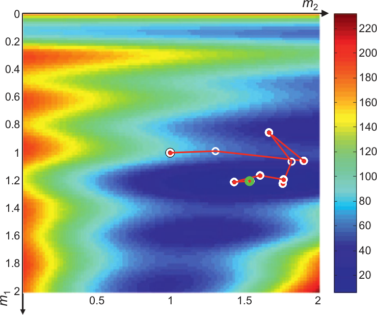

Monte Carlo method